# Assignment 12

30 min: Perform a bivariate analysis on at least 3 combinations of a numerical column with a categorical column in the dataset that you chose in portfolio assignment 4. Use *.groupby('columnname').mean()* to calculate the means. Is there a difference between categories? Then use seaborn barplots to check if there is a statistically significant difference.

```python
import matplotlib.pyplot as plt
import pandas as pd
import seaborn as sns
pokémon = pd.read_csv('pokemon.csv', sep=',')
pokémon.head()
```

|  | # | Name | Type 1 | Type 2 | Total | HP | Attack | Defense | Sp. Atk | Sp. Def | Speed | Generation | Legendary |
| --- | --- | --- | --- | --- | --- | --- | --- | --- | --- | --- | --- | --- | --- |
| 0 | 1 | Bulbasaur | Grass | Poison | 318 | 45 | 49 | 49 | 65 | 65 | 45 | 1 | False |
| 1 | 2 | Ivysaur | Grass | Poison | 405 | 60 | 62 | 63 | 80 | 80 | 60 | 1 | False |
| 2 | 3 | Venusaur | Grass | Poison | 525 | 80 | 82 | 83 | 100 | 100 | 80 | 1 | False |
| 3 | 3 | VenusaurMega Venusaur | Grass | Poison | 625 | 80 | 100 | 123 | 122 | 120 | 80 | 1 | False |
| 4 | 4 | Charmander | Fire | NaN | 309 | 39 | 52 | 43 | 60 | 50 | 65 | 1 | False |

## (1/3) Type 1 en de Attack

Er is een duidelijk verschil wat betreft de sterkte van de Attack end e verschillende type pokémon die er zijn. Zo is duidelijk te zien dat pokémon van het type fighting, ground, dragon, rock en steel een veel hogere aanval hebben wat logisch is omdat het sterkere materialen zijn en het met vechten komt natuurlijk een sterke aanval.

Pokémons met een lage aanval zijn Bug, Fairy, ghost en grass en dat is ook logisch omdat ze bijvoorbeeld klein, meer schattig of andere kwaliteiten hebben.

```python
Type1AndAttack = pokémon[['Type 1', 'Attack']]
Type1AndAttack.groupby('Type 1').mean()
```

| Type 1 | Attack |
| --- | --- |
| Bug | 70.971014 |
| Dark | 88.387097 |
| Dragon | 112.125000 |
| Electric | 69.090909 |
| Fairy | 61.529412 |
| Fighting | 96.777778 |
| Fire | 84.769231 |
| Flying | 78.750000 |
| Ghost | 73.781250 |
| Grass | 73.214286 |
| Ground | 95.750000 |
| Ice | 72.750000 |
| Normal | 73.469388 |
| Poison | 74.678571 |
| Psychic | 71.456140 |
| Rock | 92.863636 |
| Steel | 92.703704 |
| Water | 74.151786 |

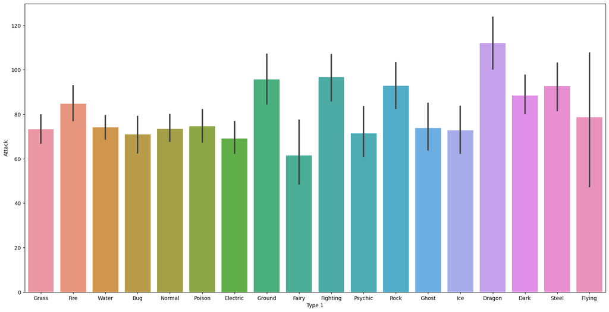

```python
plt.rcParams["figure.figsize"] = (20,10)
sns.barplot(x="Type 1", y="Attack", data=pokémon)
```

## (2/3) Legendary en de HP

```python
LegendaryAndHP = pokémon[['Legendary', 'HP']]
LegendaryAndHP.groupby('Legendary').mean()
```

| Legendary | HP |
| --- | --- |
| False | 67.182313 |
| True | 92.738462 |

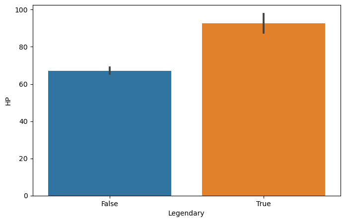

```python
plt.rcParams["figure.figsize"] = (8,5)
sns.barplot(x="Legendary", y="HP", data=pokémon)
```

## (3/3) Type 2 en de Speed

Er is een duidelijk verschil tussen de snelheid van verschillende type pokémon. Hiervoor kijken we naar het tweede type van elke pokémon.

Typen zoals dragon, Fighting en Flying zijn juist erg snel omdat ze of kunnen vliegen of gespierd zijn en daardoor snel kunnen rennen. Normal type is ook erg snel maar daarvoor heb ik geen verklaring.

```python
Type2AndSpeed = pokémon[['Type 2', 'Speed']]
Type2AndSpeed.groupby('Type 2').mean()
```

| Type 2 | Speed |
| --- | --- |
| Bug | 61.666667 |
| Dark | 75.350000 |
| Dragon | 80.555556 |
| Electric | 71.500000 |
| Fairy | 61.217391 |
| Fighting | 87.384615 |
| Fire | 79.666667 |
| Flying | 85.721649 |
| Ghost | 53.857143 |
| Grass | 57.320000 |
| Ground | 54.657143 |
| Ice | 74.642857 |
| Normal | 89.250000 |
| Poison | 66.647059 |
| Psychic | 69.484848 |
| Rock | 36.000000 |
| Steel | 59.363636 |
| Water | 57.142857 |

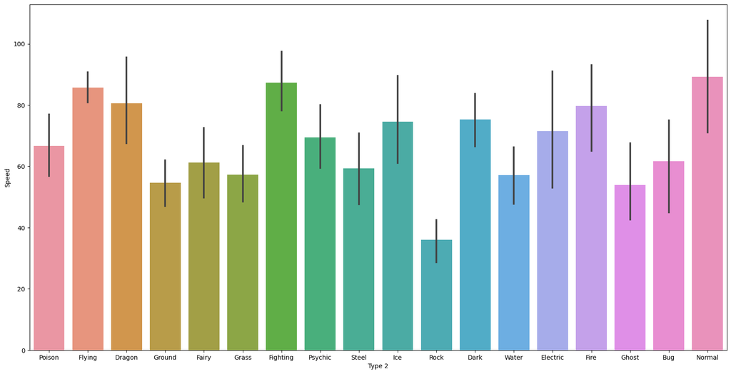

```python
plt.rcParams["figure.figsize"] = (20,10)
sns.barplot(x="Type 2", y="Speed", data=pokémon)
```